# Kit comparison

- Samples: same UHRR + 1% synthetic ERCC control input (10 ng), prepared with kits from different vendors.
- Salmon used to generate pseudocounts from transcriptome
- STAR used to map the reads onto genome

### Kit should:

1. Produce clean RNA with high yeild
2. Be unbiased (or biased?) towards fragment sizes
3. Carry low rRNA leftovers
4. Include highest diversity of transcripts and low number of duplicates.
5. Include High abundance transcripts
6. Summary

### 1. High Yeild

**What is the concentration of each library (from same starting material)?**  
I can not answer this question.

```python
# load the pseudocounts and other data obtained with Salmon for kit1 and kit2
%pylab inline
import os,re
import numpy as np
import pandas as pd
from library import *

kit1 = pd.read_csv('./kit1/quant.sf', index_col=0, delimiter='\t')
kit2 = pd.read_csv('./kit2/quant.sf', index_col=0, delimiter='\t')
list(kit1.columns)
```

```
['Length', 'EffectiveLength', 'TPM', 'NumReads']
```

### 1'. Do we get the similar results with kit1 and kit2?

```python
from scipy.stats import spearmanr
Sr = spearmanr(kit1.TPM, kit2.TPM)[0]
Pr = np.corrcoef(kit1.TPM, kit2.TPM)[0][1]

# absolute differences of TPM between samples
# a difference of 0 is probable due to 0 TPMs in both kits
diff = np.abs(kit1.TPM-kit2.TPM)

# merge TPM values with diff in same matrix  columns = [kit1, kit2, diff]
tpm = pd.concat([kit1.TPM, kit2.TPM, diff],axis=1).values

# select for transcripts with 0 in both kits
just_zeros = tpm[(tpm[:,0]==0) & (tpm[:,1]==0)].shape[0]

# Report findings
print('There are {} transcripts with 0 TPM in both samples. This is {:.1f}% of the transcriptome.'.format(just_zeros, just_zeros/kit1.shape[0]*100))
print('{} transcripts have same number of TPMs (0) compated to {} transcripts with different TPM between kits.'.format(\
                                                                                                            np.sum(tpm[:,2]==0), np.sum(tpm[:,2]!=0)))
print('There are {} transcripts with 0 TPMs in kit1 and {} in kit2'.format(np.sum(kit1.TPM==0), np.sum(kit2.TPM==0)))
print('Pearson (kit1-TPM vs kit2-TPM)= {:.2f}, Spearman={:.2f}'.format(Pr, Sr))
```

```
There are 63455 transcripts with 0 TPM in both samples. This is 32.0% of the transcriptome.
63456 transcripts have same number of TPMs (0) compated to 134729 transcripts with different TPM between kits.
There are 84553 transcripts with 0 TPMs in kit1 and 83605 in kit2
Pearson (kit1-TPM vs kit2-TPM)= 0.93, Spearman=0.74
```

In general, **~20000** transcripts have **TPM=0 in one kit** but TPM>0 in the other.

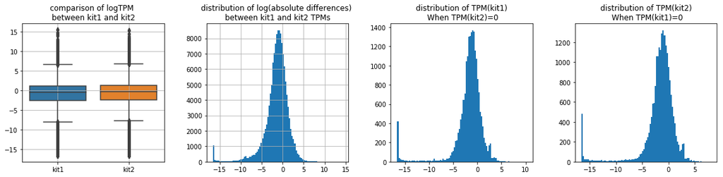

```python
# Plot differences of TPM for each transcript between the two kits.
plt.figure(figsize=(16,4))

# logarithm of the differences.
# 0 in kit1 AND kit2 are discarded. Small number added to avoid log(0) - it's relatively easy recognized in a plot.
log_tpm = np.log2(tpm[tpm[:,2]>0]+10e-6)

# plot distribution of TPM in both experiments (taking out transcripts with 0 TPM in kit1 AND kit2)
# reminder: columns = [kit1.TPM, kit2.TPM, diff]
import seaborn
plt.subplot(141)
plt.title('comparison of logTPM \nbetween kit1 and kit2')
ax = seaborn.boxplot(data=log_tpm[:,:2]); ax.set_xticklabels(['kit1','kit2'])
ax.grid()

# plot histogram to represent the distribution of differences in TPM between transcripts form both kits (including ONLY transcripts with TPM>0)
plt.subplot(142)
plt.title('distribution of log(absolute differences) \nbetween kit1 and kit2 TPMs')
plt.hist(log_tpm[:,2], bins=100)
plt.grid()

# plot distribution of TPM for kit1 --> FOR SAMPLES WITH TPM==0 IN kit2.
plt.subplot(143)
plt.title('distribution of TPM(kit1)\n When TPM(kit2)=0')
values = tpm[(tpm[:,1]==0) & (tpm[:,0]>0)][:,0]          # for ~65000, TPM=0 in kit1 & kit2 => plot logTPM for the other ~20000 transcripts
plt.hist(np.log2(values + 10e-6), bins=100)

# same but avoiding the 0 values
plt.subplot(144)
plt.title('distribution of TPM(kit2)\n When TPM(kit1)=0')
values = tpm[(tpm[:,0]==0) & (tpm[:,1]>0)][:,1]          # for ~65000, TPM=0 in kit1 & kit2 => plot logTPM for the other ~20000 transcripts
plt.hist(np.log2(values + 10e-6), bins=100);
plt.tight_layout()
```

Distribution of TPM in kit1 for transcripts without reads in kit2 do not look different from the distribution of TPMs in kit2 for transcripts without reads in kit1.  
In 5 I will analyze blocks of increasing TPMs or quantiles and compare these blocks between the two kits.  
I am interested in transcripts with high discrepancy in TPMs between both experiments.

```
there are 547 transcripts with>2^5 difference in their TPM
Theses transcripts, while TPM=0 in one kit are mid-high abundance in the other kit
```

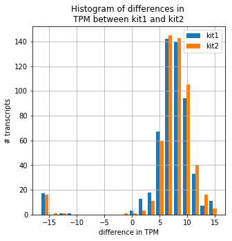

```python
# transcripts with high discrepancy in TPMs between kits
discrep = tpm[tpm[:,2]>2**5]

# plot historgram of TPM from dicrepancy transcripts
plt.figure(figsize=(5,5))
plt.hist(np.log2(discrep[:,:2]+10e-6), bins=20)
plt.title('Histogram of differences in \nTPM between kit1 and kit2')
plt.ylabel('# transcripts')
plt.xlabel('difference in TPM')
plt.legend(['kit1','kit2'])
plt.grid();

# print results
print('there are {} transcripts with>2^5 difference in their TPM'.format(tpm[tpm[:,2]>2**5].shape[0]))
print('Theses transcripts, while TPM=0 in one kit are mid-high abundance in the other kit')
```

### 2. Is there a bias of mRNA purification towards certain fragment sizes in kit1 or kit2?

```
(0, 150)
```

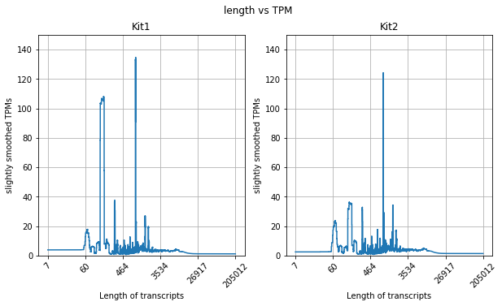

```python
# plot figure of length vs TPM
plt.figure(figsize=(10,5))
plt.suptitle('length vs TPM')

ax = plt.subplot(121)
plt.title('Kit1')
x,y = TPM_vs_Length(kit1, ax)
plt.ylim(0,150)

ax = plt.subplot(122)
plt.title('Kit2')
x,y = TPM_vs_Length(kit2, ax)
plt.ylim(0,150)
```

There might be a difference. Kit1 might tend to keep more mRNAs within a specific window of lengths (short to mid long).

### 3. Low rRNA content

For this purpose, I aligned the reads to the human genome with STAR and search for rRNAs in a corresponding gtf file. I realized that STAR (with parameters and files that I supplied with) was far from optimal and retrieved a much lower number of isoforms of transcripts for each gene compared to Salmon. Nevertheless, the only purpose of aligning to the genome was to avoid potential missing regions corresponding to rRNAs in the fasta file containing the transcriptome, that has been provided to me.

```
rRNA leftover (kit1 / kit2) = 0.84
```

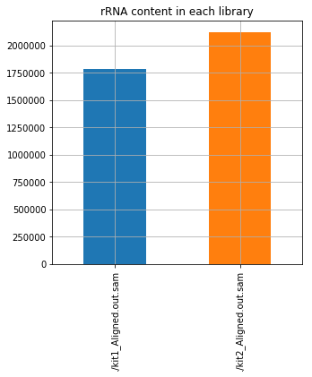

```python
# genes contains output of FeatureCounts from subread package
genes = pd.read_csv('./STAR_results/featureCounts.output.clean', index_col=0, delimiter='\t')

# rRNAs contains the number of reads mapped to each ribosomal RNA
rRNAs = pd.read_csv('./STAR_results/rRNAs', index_col=0, header=None, names=['genes'])

# translate transcript name to gene name and viceversa (possible collisions - more than 1 transcript for 1 gene)
table = pd.read_csv('./STAR_results/hashTable', index_col=1, header=None, delimiter='\t', names=['transcript'])

# translate RNAs to transcript names
RNAs = table.loc[rRNAs.index]

# dataframe contains the number of reads associated with rRNAs for each kit
rna_leftovers = genes.loc[RNAs.transcript].sum(axis=0)

# Bar plot. number of reads associated to rRNAs for each kit
plt.title('rRNA content in each library')
rna_leftovers.plot.bar(figsize=(5,5))
plt.grid()

# print the ratio of rRNA carried with the mRNA for kit1 over kit2
ratio_1_2 = rna_leftovers[0] *1./ rna_leftovers[1]
print('rRNA leftover (kit1 / kit2) = {:.2f}\n'.format(ratio_1_2))
```

The ammount of ribosomal RNA carried in each library, the way that I am measuring it, seem to be similar. Nevertheless, **kit1 have less**.

### 4. What is the diversity of the library?

- Count number of unique species

```python
print('kit1 has {} unique species'.format(np.sum(kit1.NumReads>0)))
print('kit2 has {} unique species'.format(np.sum(kit2.NumReads>0)))
print('kit1/kit2 = {:.2f}'.format(np.sum(kit1.NumReads>0) *1. / np.sum(kit2.NumReads>0)))
```

```
kit1 has 113632 unique species
kit2 has 114580 unique species
kit1/kit2 = 0.99
```

**kit2** has ~1000 **more transcripts** with *"some"* signal

- What is the number of *"same"* fragments in each library? I called these fragments *"same"* since I don't know how were these libraries prepared (e.g. polyT primer?) and therefore I can't assume that exact same reads would be duplicate reads.  
  I've splitted the sam files into smaller files, that can be accomodated fast in the memory of the computer.  
  Filenames are _"kit1_aa, kit_ab... and kit2*aa..."*.  
  Instead of measuring the whole set of mapped reads, I take samples and report the mean value (it should be close the real value)

```python
for kit in ['kit1', 'kit2']:
    # average_kit is the average abundance of duplicates in the sample
    average_kit=[]
    # sub_sample_files lists all splitted files corresponding to a sam file (which correspond to one kit)
    for file in sub_sam_files(kit):
        # open sam file into a list "k" of strings encoding chromosome number, start and length.
        # Two fragments with equal values are considered duplicates
        k = sam('./STAR_results/'+file)
        # total and unique number of fragments in the sam file
        total = len(k)
        uniq = len(set(k))
        # proporton of duplicate fragments in the sam file.
        average_kit.append((total-uniq) *1. / total)
    # get average of duplicates, considering all sam subsamples
    average_kit = np.sum(average_kit) / len(average_kit)
    print('Fraction of same sequences in {} is {:.3f}'.format(kit, average_kit))
```

```
Fraction of same sequences in kit1 is 0.264
Fraction of same sequences in kit2 is 0.308
```

It looks like **kit2** has **higher abundance of "same" fragments**. I can't assume that these are duplicates.